**산업체 재직자 대상 인공지능 핵심 기초 교육**  
**Semiconductor Wafer Failure Map Classification**

By Prof. Seungchul Lee  
http://iai.postech.ac.kr/  
Industrial AI Lab at POSTECH

# Contents

1. Understand the convolution neural networks (CNN)
2. Recognize and analyze the wafer failures map data (WM-811k)
3. Pre-processing for image data, build and train CNN model.

```python
%matplotlib inline

import os
import numpy as np
import pandas as pd
import matplotlib.pyplot as plt
import tensorflow as tf
import keras
import warnings
import sklearn
from os.path import join
from keras import layers, Input, models
from sklearn.model_selection import train_test_split
```

# 1. Convolution

## 1.1. 1D Convolution

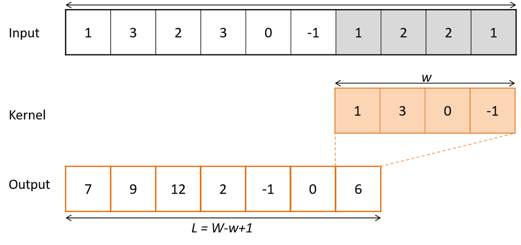

## 1.2. Images

[figure not shown]

## 1.3. Convolution on Image (= Convolution in 2D)

**Filter (or Kernel)**

- Modify or enhance an image by filtering
- Filter images to emphasize certain features or remove other features
- Filtering includes smoothing, sharpening and edge enhancement
- Discrete convolution can be viewed as element-wise multiplication by a matrix

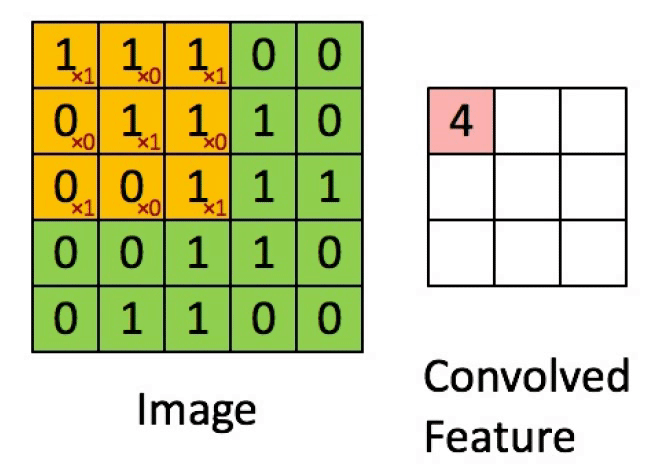

[figure not shown]

**How to find the right Kernels**

- We learn many different kernels that make specific effect on images
- Let’s apply an opposite approach
- We are not designing the kernel, but are learning the kernel from data
- Can learn feature extractor from data using a deep learning framework

# 3. Semiconductor Wafer Failure Maps

## 3.1. Data Description

- Wafer failure classification for process analysis in semoconductor fields.

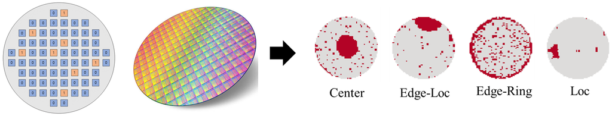

## 3.2 Load data

```python
from google.colab import drive
drive.mount('/content/drive')
```

```python
df=pd.read_pickle('/content/drive/MyDrive/linc/data_files/wafers.pkl')
```

```python
df.head()
```

|  | level_0 | index | waferMap | dieSize | lotName | waferIndex | trianTestLabel | failureType | failureNum | waferMapDim | encoded_labels |
| --- | --- | --- | --- | --- | --- | --- | --- | --- | --- | --- | --- |
| 0 | 43 | 44 | [[0, 0, 0, 0, 0, 0, 0, 0, 0, 0, 0, 0, 0, 0, 0,... | 2460.0 | lot2 | 20.0 | [[Training]] | [[Center]] | 0 | (53, 58) | 2 |
| 1 | 47 | 49 | [[0, 0, 0, 0, 0, 0, 0, 0, 0, 0, 0, 0, 0, 0, 0,... | 2460.0 | lot2 | 25.0 | [[Training]] | [[Center]] | 0 | (53, 58) | 2 |
| 2 | 543 | 604 | [[0, 0, 0, 0, 0, 0, 0, 0, 0, 0, 1, 2, 1, 2, 1,... | 533.0 | lot25 | 5.0 | [[Training]] | [[Center]] | 0 | (26, 26) | 2 |
| 3 | 645 | 729 | [[0, 0, 0, 0, 0, 0, 0, 0, 0, 0, 1, 1, 1, 2, 1,... | 533.0 | lot30 | 5.0 | [[Training]] | [[Center]] | 0 | (26, 26) | 2 |
| 4 | 783 | 893 | [[0, 0, 0, 0, 0, 0, 0, 0, 0, 0, 1, 2, 1, 1, 2,... | 533.0 | lot36 | 19.0 | [[Training]] | [[Center]] | 0 | (26, 26) | 2 |

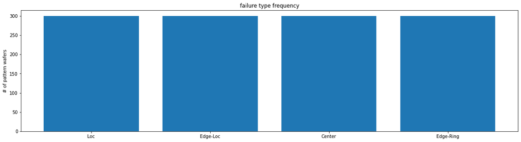

```python
import matplotlib.pyplot as plt
from matplotlib import gridspec
fig = plt.figure(figsize=(20, 5))
uni_pattern=np.unique(df.failureNum, return_counts=True)
labels = ['Loc', 'Edge-Loc', 'Center', 'Edge-Ring']
plt.bar(uni_pattern[0],uni_pattern[1])
plt.title("failure type frequency")
plt.ylabel("# of pattern wafers")
plt.xticks(np.arange(4),labels)
plt.show()
```

## 3.3 Image pre-processing

- Different image size --> image resizing

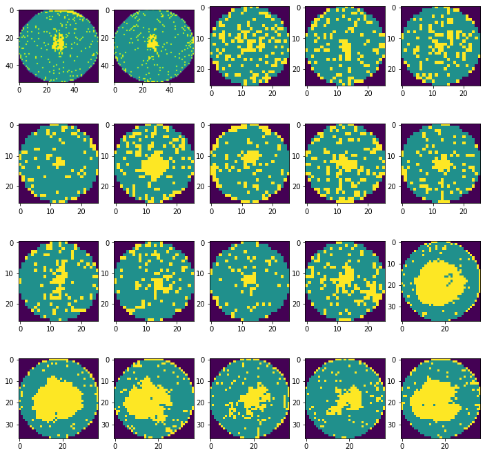

```python
plt.figure(figsize=(12,12))
for i in range(20):
    ax = plt.subplot(4, 5, i+1)
    ax.imshow(df["waferMap"][i])
```

```python
df.head()
```

|  | level_0 | index | waferMap | dieSize | lotName | waferIndex | trianTestLabel | failureType | failureNum | waferMapDim | encoded_labels |
| --- | --- | --- | --- | --- | --- | --- | --- | --- | --- | --- | --- |
| 0 | 43 | 44 | [[0, 0, 0, 0, 0, 0, 0, 0, 0, 0, 0, 0, 0, 0, 0,... | 2460.0 | lot2 | 20.0 | [[Training]] | [[Center]] | 0 | (53, 58) | 2 |
| 1 | 47 | 49 | [[0, 0, 0, 0, 0, 0, 0, 0, 0, 0, 0, 0, 0, 0, 0,... | 2460.0 | lot2 | 25.0 | [[Training]] | [[Center]] | 0 | (53, 58) | 2 |
| 2 | 543 | 604 | [[0, 0, 0, 0, 0, 0, 0, 0, 0, 0, 1, 2, 1, 2, 1,... | 533.0 | lot25 | 5.0 | [[Training]] | [[Center]] | 0 | (26, 26) | 2 |
| 3 | 645 | 729 | [[0, 0, 0, 0, 0, 0, 0, 0, 0, 0, 1, 1, 1, 2, 1,... | 533.0 | lot30 | 5.0 | [[Training]] | [[Center]] | 0 | (26, 26) | 2 |
| 4 | 783 | 893 | [[0, 0, 0, 0, 0, 0, 0, 0, 0, 0, 1, 2, 1, 1, 2,... | 533.0 | lot36 | 19.0 | [[Training]] | [[Center]] | 0 | (26, 26) | 2 |

```
<BarContainer object of 75 artists>
```

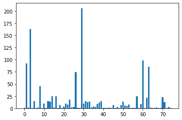

```python
sizes = df.waferMapDim.values
unique_size, count_for_size = np.unique(sizes, return_counts=True)
plt.bar(range(len(unique_size)),count_for_size)
```

- Resizing for same size

```python
from PIL import Image
def resizing(img):
    img_tmp = img.copy()
    img_tmp = Image.fromarray(img_tmp)
    img_tmp = img_tmp.resize((32,32))
    img_tmp = np.array(img_tmp)
    return img_tmp

df['waferMap_resized'] = df['waferMap'].apply(resizing)
```

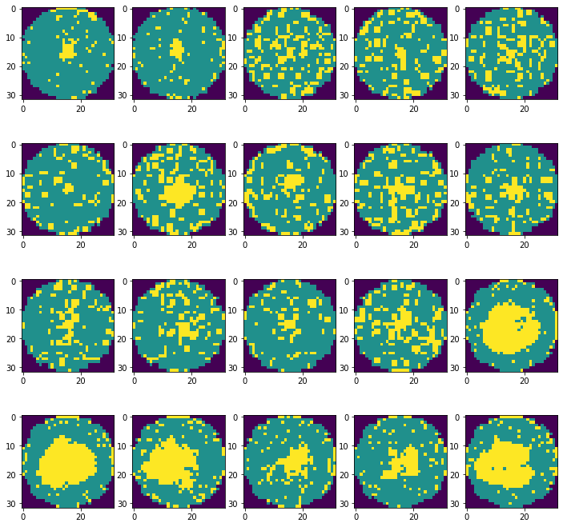

```python
plt.figure(figsize=(12,12))
for i in range(20):
    ax = plt.subplot(4, 5, i+1)
    ax.imshow(df["waferMap_resized"][i])
```

- Data split: train/test

```python
all_x = df['waferMap_resized'].values
all_y = df['encoded_labels'].values
train_x, test_x, train_y, test_y = \
train_test_split(all_x, all_y, test_size=0.2, random_state=42)
```

```python
print(train_y.shape)
print(test_y.shape)
```

```
(960,)
(240,)
```

```python
train_x = np.stack(train_x).reshape(-1,32,32,1)
train_y = np.stack(train_y)

test_x = np.stack(test_x).reshape(-1,32,32,1)
test_y = np.stack(test_y)
```

```python
print('Train x : {}, y : {}'.format(train_x.shape, train_y.shape))
print('Test x: {}, y : {}'.format(test_x.shape, test_y.shape))
```

```
Train x : (960, 32, 32, 1), y : (960,)
Test x: (240, 32, 32, 1), y : (240,)
```

## 3.4 Train and results

The data is ready. As wafer data is image. simply use cnn for classification.

define create model function

- Build CNN model

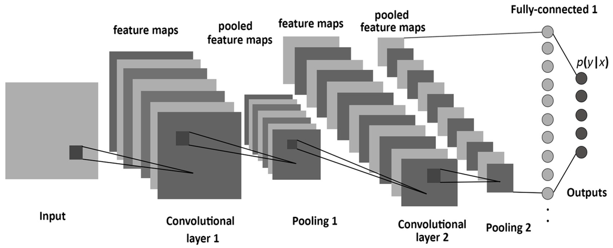

```python
model = tf.keras.models.Sequential([
    tf.keras.layers.Conv2D(32, (3,3), activation='relu', padding = 'SAME', input_shape=(32, 32, 1)),
    tf.keras.layers.MaxPool2D((2,2)),
    tf.keras.layers.Conv2D(64, (3,3), activation='relu', padding = 'SAME', input_shape=(14, 14, 32)),
    tf.keras.layers.MaxPool2D((2,2)),
    tf.keras.layers.Flatten(input_shape=(7,7)),
    tf.keras.layers.Dense(32, activation='relu'),
    tf.keras.layers.Dense(4, activation='softmax')
])

model.summary()
```

```
Model: "sequential"
_________________________________________________________________
 Layer (type)                Output Shape              Param #
=================================================================
 conv2d (Conv2D)             (None, 32, 32, 32)        320

 max_pooling2d (MaxPooling2D  (None, 16, 16, 32)       0
 )

 conv2d_1 (Conv2D)           (None, 16, 16, 64)        18496

 max_pooling2d_1 (MaxPooling  (None, 8, 8, 64)         0
 2D)

 flatten (Flatten)           (None, 4096)              0

 dense (Dense)               (None, 32)                131104

 dense_1 (Dense)             (None, 4)                 132

=================================================================
Total params: 150,052
Trainable params: 150,052
Non-trainable params: 0
_________________________________________________________________
```

- Training

```python
model.compile(optimizer='adam',
                loss='sparse_categorical_crossentropy',
                metrics=['accuracy'])
```

```python
batch_size = 32
history = model.fit(train_x, train_y,
         epochs=10,
         batch_size=batch_size,
         )
```

```python
history.history.keys()
```

```
dict_keys(['loss', 'accuracy'])
```

- Learning curve

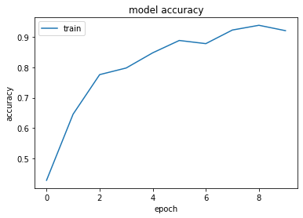

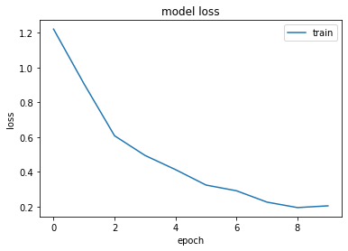

```python
# accuracy plot
plt.plot(history.history['accuracy'])
plt.title('model accuracy')
plt.ylabel('accuracy')
plt.xlabel('epoch')
plt.legend(['train', 'test'])
plt.show()

# loss plot
plt.plot(history.history['loss'])
plt.title('model loss')
plt.ylabel('loss')
plt.xlabel('epoch')
plt.legend(['train', 'test'])
plt.show()
```

- Test result

```python
test_loss, test_acc = model.evaluate(test_x,  test_y, verbose=2)

print('loss = {}, Accuracy = {} %'.format(test_loss, test_acc * 100))
```

```
8/8 - 0s - loss: 0.3821 - accuracy: 0.8667 - 212ms/epoch - 26ms/step
loss = 0.38210809230804443, Accuracy = 86.66666746139526 %
```

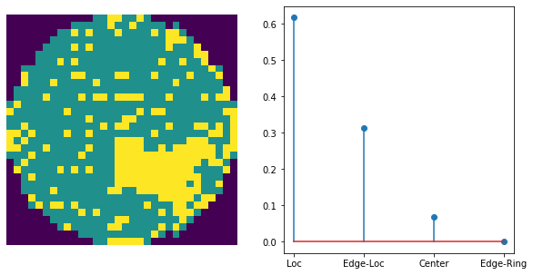

```
Prediction : 0
Probability : [0.6175432  0.3143088  0.06743356 0.00071444]
```

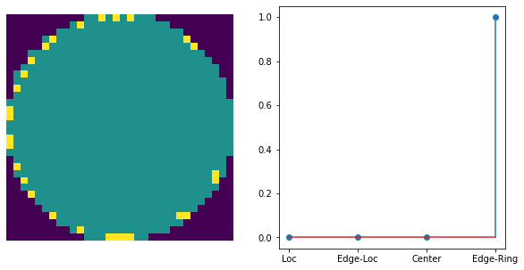

```
Prediction : 3
Probability : [3.5314442e-05 2.3259704e-04 2.9046307e-04 9.9944156e-01]
```

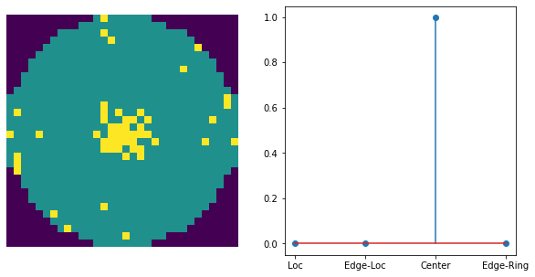

```
Prediction : 2
Probability : [1.8429352e-03 5.6025921e-04 9.9752837e-01 6.8468551e-05]
```

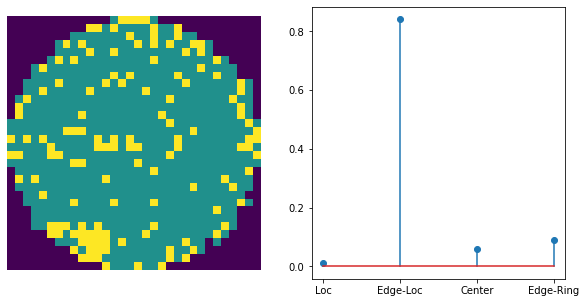

```
Prediction : 1
Probability : [0.01204322 0.84130996 0.05791468 0.08873214]
```

```python
pred_y = model.predict_on_batch(test_x[:4])

idx = tf.math.argmax(pred_y, axis = 1)
for i, el in enumerate(test_x[:4]):
    plt.figure(figsize = (10,5))
    plt.subplot(1,2,1)
    plt.imshow(el.reshape(32, 32), clim=[0,2])
    plt.axis('off')

    plt.subplot(1,2,2)
    plt.stem(pred_y[i])
    plt.xticks(np.arange(4), ['Loc', 'Edge-Loc', 'Center', 'Edge-Ring'])  # Set text labels.
    plt.show()
    print('Prediction : {}'.format(np.argmax(pred_y[i])))
    print('Probability : {}'.format(pred_y[i]))
```

- Confusion matrix

```python
import seaborn as sns
from sklearn.metrics import confusion_matrix
#Predict
pred_y = model.predict(test_x)
pred_y = np.argmax (pred_y, axis = 1)
result = confusion_matrix(test_y, pred_y , normalize='pred')
print(result)
```

```
[[1.         0.22222222 0.13333333 0.        ]
 [0.         0.76388889 0.04       0.03278689]
 [0.         0.         0.82666667 0.        ]
 [0.         0.01388889 0.         0.96721311]]
```

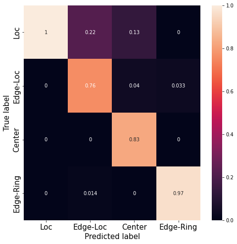

```python
plt.figure(figsize=(8,8))
heatmap = sns.heatmap(result, annot=True)
heatmap.yaxis.set_ticklabels(labels,fontsize=15)
heatmap.xaxis.set_ticklabels(labels,fontsize=15)
plt.ylabel('True label',fontsize=15)
plt.xlabel('Predicted label',fontsize=15)
```

# 4. Data augmentation

## 4.1 Data rotation

- Rotating for trainset augmentation

```python
train_x_90 = tf.image.rot90(train_x, k=1)
train_x_180 = tf.image.rot90(train_x, k=2)
train_x_270 = tf.image.rot90(train_x, k=3)

train_x_augmented = np.concatenate((train_x, train_x_90, train_x_180, train_x_270), axis = 0)
train_y_augmented = np.array(list(train_y) + list(train_y)*3)
```

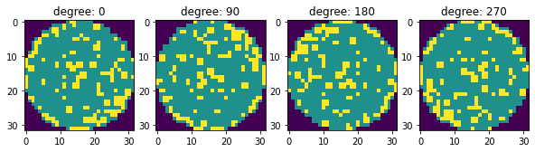

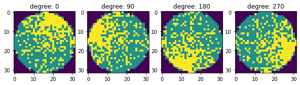

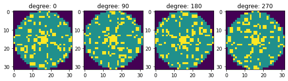

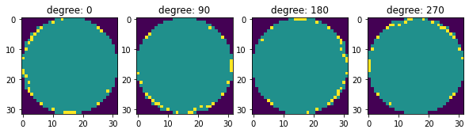

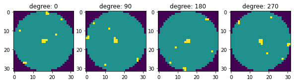

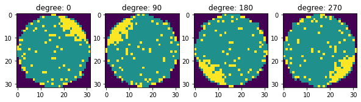

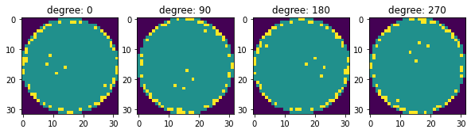

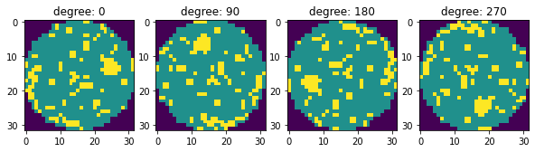

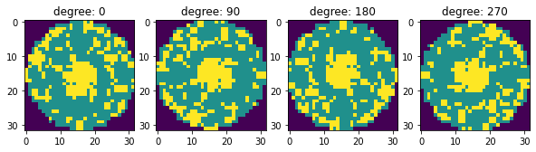

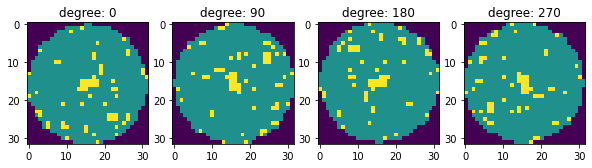

```python
for i in range(10):
    fig, (ax1, ax2, ax3,ax4) = plt.subplots(ncols=4, figsize=(10, 10))
    ax1.set_title('degree: 0')
    ax2.set_title('degree: 90')
    ax3.set_title('degree: 180')
    ax4.set_title('degree: 270')
    ax1.imshow(train_x[i,:,:,0])
    ax2.imshow(train_x_90[i,:,:,0])
    ax3.imshow(train_x_180[i,:,:,0])
    ax4.imshow(train_x_270[i,:,:,0])
```

```python
uni_pattern_trainset = np.unique(train_y, return_counts=True)
uni_pattern_trainset_rotated = np.unique(train_y_augmented, return_counts=True)
```

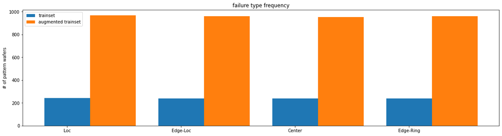

```python
fig = plt.figure(figsize=(20, 5))
labels = ['Loc', 'Edge-Loc', 'Center', 'Edge-Ring']
plt.bar(uni_pattern_trainset[0],uni_pattern_trainset[1],0.4, label='trainset')
plt.bar(uni_pattern_trainset_rotated[0]+0.4,uni_pattern_trainset_rotated[1],0.4, label='augmented trainset')
plt.title("failure type frequency")
plt.ylabel("# of pattern wafers")
plt.legend()
plt.xticks(np.arange(4),labels)
plt.show()
```